# 單一樣本假設檢定

陳威呈、戴瑜萱

```r
library(Rcmdr)
library(car)
library(RcmdrMisc)
```

# **比例檢定**

## 範例

#### 某投資顧問公司欲了解民眾的網路成癮程度，了解使用者的差異性，以提供遊戲業者參考使用，蒐集了一份資料，資料為喜歡玩線上遊戲的男性人數，受訪男性有350人而高度網路使用者則紀錄為0，非高度網路使用者則紀錄為1。我們欲檢定男性的非高度網路使用者之比例是否大於70%，

```r
s<-read.csv("s.csv")
```

```r
s <- subset(s, select=c(MALE))
```

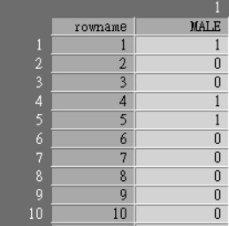

[figure not shown]

[figure not shown]

```r
s <- within(s, {
  MALE <- as.factor(MALE)
})
```

[figure not shown]

[figure not shown]

[figure not shown]

```r
local({
  .Table <- xtabs(~ MALE , data= s )
  cat("\nFrequency counts (test is for first level):\n")
  print(.Table)
  prop.test(rbind(.Table), alternative='less', p=.7, conf.level=.95,
  correct=FALSE)
})
```

```
##
## Frequency counts (test is for first level):
## MALE
##   0   1
## 267  83
```

```
##
##  1-sample proportions test without continuity correction
##
## data:  rbind(.Table), null probability 0.7
## X-squared = 6.585, df = 1, p-value = 0.9949
## alternative hypothesis: true p is less than 0.7
## 95 percent confidence interval:
##  0.0000000 0.7981472
## sample estimates:
##         p
## 0.7628571
```

# **平均數或中位數檢定整理**

- n large, variance known or unknown =>z-test (備註2, 誤用 t-test 問題不大)
- n small, normal & variance known => z-test (備註2)
- n small, normal & variance unknown => t-test  
  （t.test vs. 統計量>平均數檢定>單一樣本T檢定）  
  http://www.instantr.com/2012/12/29/performing-a-one-sample-t-test-in-r/
- n small, maybe non-normal but symmetric => Wilcoxon signed rank test  
  （wilcox.test vs. 統計量>無母數檢定>單一樣本Wilcoxon檢定）  
  https://molecular-service-science.com/2012/05/06/wilcoxon-signed-rank-test/
- n small, maybe asymmetric => sign test (備註3)

# **平均數檢定**

#### 今天要抽查某咖啡店的咖啡(Cofee為常態分布)

## 雙尾

a.咖啡店號稱每一杯都是250公克(雙尾檢定) 抽查結果如下

```r
Coffee<-data.frame(gram=c(254.1,253.5,257.3,250.6,243.5,244.6,251.5,
          251.4,251.7,242.5,254.5,250.9,251.4,248.2,
          249.4,248.3,246.9,249.6,250.5,247.5))
```

### 使用 R Commander 分析

[figure not shown]

[figure not shown]

### 使用命令列語法

設定alternative hypothesis($H_a$)為two.sided  
設定null hypothesis($H_0$) 為 $\mu=250$

```r
with(Coffee, (t.test(gram, alternative='two.sided', mu=250, conf.level=.95)))
```

```
##
##  One Sample t-test
##
## data:  gram
## t = -0.12621, df = 19, p-value = 0.9009
## alternative hypothesis: true mean is not equal to 250
## 95 percent confidence interval:
##  248.1537 251.6363
## sample estimates:
## mean of x
##   249.895
```

我們可以發現p-value大於0.05，因此我們不能拒絕$H_0$，也就是說我們沒有證據推翻咖啡每杯是250克的說法。

## 單尾

### 使用 R Commander 分析

[figure not shown]

### 使用命令列語法

```r
with(Coffee, (t.test(gram, alternative='greater', mu=220, conf.level=.95)))
```

```
##
##  One Sample t-test
##
## data:  gram
## t = 35.933, df = 19, p-value < 2.2e-16
## alternative hypothesis: true mean is greater than 220
## 95 percent confidence interval:
##  248.4564      Inf
## sample estimates:
## mean of x
##   249.895
```

我們可以發現p-value小於0.05，因此我們拒絕$H_0$，也就是有證據顯示咖啡每杯是220克以下的說法是不對的。

# **中位數檢定**

## 範例1

#### 泡泡清潔用品公司宣稱其所生產的沐浴乳每瓶重量的中位數為200公克，今隨機抽查12瓶，得重量如下：211 203 206 213 192 205 195 198 204 216 207 222，顯著水準是0.05，檢定該公司的宣稱是否正確？

```r
a<-read.csv("a.csv")
```

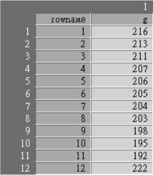

[figure not shown]

[figure not shown]

[figure not shown]

```r
with(a, median(g, na.rm=TRUE))
```

```
## [1] 205.5
```

```r
with(a, mean(g, na.rm=TRUE))
```

```
## [1] 206
```

```r
with(a, wilcox.test(g, alternative='two.sided', mu=200))
```

```
##
##  Wilcoxon signed rank test with continuity correction
##
## data:  g
## V = 64.5, p-value = 0.04977
## alternative hypothesis: true location is not equal to 200
```

由上述結果可知中間值是205.5，平均值是206，p值是0.04977，因為p值小於顯著水準，所以拒絕虛無假設，中位數不等於200公克

## 範例2

#### 郵局的辦事小姐處理隨機選取的16位顧客的郵寄業務所花的時間如下：0.8 0.7 0.9 3.8 2.6 1.2 2.9 0.5 0.8 2.7 0.6 6.2 2.8 1.3 1.5 1.7，檢定處理每件業務所花時間的中位數是否大於1分鐘？

```r
b<-read.csv("b.csv")
```

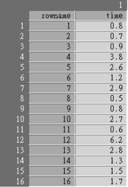

[figure not shown]

[figure not shown]

```r
with(b, median(time, na.rm=TRUE))
```

```
## [1] 1.4
```

```r
with(b, mean(time, na.rm=TRUE))
```

```
## [1] 1.9375
```

```r
with(b, wilcox.test(time, alternative='less', mu=1.0))
```

```
##
##  Wilcoxon signed rank test with continuity correction
##
## data:  time
## V = 108, p-value = 0.982
## alternative hypothesis: true location is less than 1
```

## 範例3

#### 某位品檢員想知道產品之中位數是否小於82公克？他隨機抽取了生產線上14件產品檢驗，得到下列數據：83.5 81.3 78.2 82 85.4 88.3 76.2 79.8 83.6 77.3 86.8 80.5 81.8 79.6。

```r
c<-read.csv("c.csv")
```

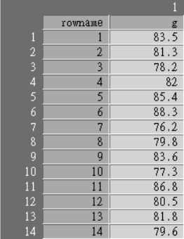

[figure not shown]

[figure not shown]

```r
with(c, median(g, na.rm=TRUE))
```

```
## [1] 81.55
```

```r
with(c, mean(g, na.rm=TRUE))
```

```
## [1] 81.73571
```

```r
with(c, wilcox.test(g, alternative='greater', mu=82))
```

```
##
##  Wilcoxon signed rank test with continuity correction
##
## data:  g
## V = 40.5, p-value = 0.6497
## alternative hypothesis: true location is greater than 82
```

# *備註1*

使用 R commander 必須將資料轉換成 data.frame 的格式，點選「資料集」按鈕才讀得到。  
點選「資料集」按鈕相當於 資料>使用中的資料集>選擇欲使用的資料集。  
若非透過R commander 的資料>管理使用中資料集的變數 增刪轉換變數，  
必須在操作完點選 資料>使用中的資料集>更新使用中的資料集 才會重新讀取更動。

# *備註2*

關於 z-test:  
R commander 中沒有直接可用的，需透過 機率分佈>連續型分佈>常態分佈> 常態分佈(百)分位數查表  
命令列指令: z.test{BSDA}

# *備註3*

關於 sign test:  
R commander 中沒有直接可用的，需透過 機率分佈>離散型分佈>二項式分佈> 二項式分佈(百)分位數查表  
命令列指令: binom.test  
http://highscope.ch.ntu.edu.tw/wordpress/?p=73977  
http://www.r-tutor.com/elementary-statistics/non-parametric-methods/sign-test

另外，BSDA中有SIGN.test()可用，更為方便，不必自己先算正負號的次數。